# Introducción al análisis de secuencias NGS - Llamado de variantes

Curso Genética y Genómica en Producción Animal

Dr. José A. Gallardo, Dr(c) Margarita Rivera.

Pontificia Universidad Católica de Valparaíso  
jose.gallardo@pucv.cl

24 June 2021

## INTRODUCCIÓN

Uno de los principales usos de la secuenciación de próxima generación es descubrir variantes genéticas o mutaciones entre individuos que pertenecen a diferentes poblaciones (Danecek et al., 2011). Con este fin, se han desarrollado tuberías que incluyen el procesamiento de grandes volúmenes de datos como el proyecto internacional [1000 genomas humanos](https://www.internationalgenome.org/), o el [proyecto chileno](http://www.1000genomas.cl/) de 1000 genomas que pretende secuenciar e identificar varianes en 1000 personas y en algunas especies endémicas de interes.

Uno de los softwares más empleados para realizar esta tarea denominada “llamado de variantes”, es [**GATK**](https://gatk.broadinstitute.org/hc/en-us), que se comprende como un kit de herramientas de análisis de genomas desarrollado por el Broad Institute de los Estados Unidos, que tiene la capacidad de realizar gran parte del análisis requerido para llamar variantes genómicas (Deatherage, 2020).

El presente trabajo tiene por objeto realizar el llamado de variantes y la anotación de una muestra secuenciada mediante el uso de GATK, Linux, vcftools y otras herramientas de anotación y visualización de la región blanco.

### FORMATO VCF

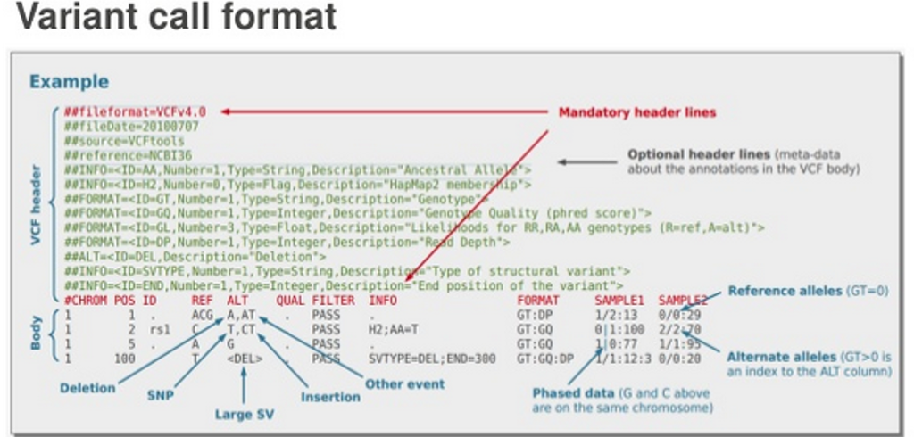

Estructura formato VCF, tomado de: https://www.slideshare.net/AmazonWebServices/dat311-largescale-genomic-analysis-with-amazon-redshift

### SOFTWARES DE BIOINFORMÁTICA

[GATK](https://gatk.broadinstitute.org/hc/en-us) O Genome Analysis Toolkit, es un software que presenta ciertas ventajas para el llamado de variantes, como, la integración de evidencia de variantes de múltiples muestras con genotipado conjunto, permite el uso de polimorfismos de un solo nucleótido (SNP) e Indels validados para mejorar la precisión de la llamada de variante y sus métodos se implementan de una manera susceptible a lecturas que se originan en una variedad de preparación de plantillas (McCormick, Truong, & Mullet, 2015). Sin embargo y aunque, como se ha visto, la precisión de esta tubería ya es alta, los falsos positivos (FP) siguen siendo inevitables, por lo que, después de la llamada de variantes, se recomienda filtrar los FP como parte de las buenas prácticas del software (Tan, Zhang, Yang, & Yin, 2020).

[PICARD TOOLS](https://broadinstitute.github.io/picard/) Es un conjunto de herramientas para manipular datos y formatos de secuenciación de alto rendimiento (HTS) como SAM / BAM / CRAM y VCF. El kit de herramientas de Picard es de código abierto y gratuito para todos los usos.

[HAPLOTYPECALLER](https://gatk.broadinstitute.org/hc/en-us/articles/360035531412-HaplotypeCaller-in-a-nutshell) Es una herramienta que contiene una serie de funciones aplicadas al descubrimiento de variantes de la línea germinal de ADN.

[vcftools](https://vcftools.github.io/index.html) VCFtools es un software diseñado para trabajar con archivos VCF, como los generados por el Proyecto 1000 Genomas. El objetivo de VCFtools es proporcionar métodos de fácil acceso para trabajar con datos complejos de variación genética en forma de archivos VCF. El manual actualizado de comandos se puede encontrar en este [link](https://vcftools.github.io/man_latest.html)

### Objetivos del trabajo práctico

- Realizar el llamado de variantes de una secuencia de *Salmo salar* obtenida por secuenciación de extremos emparejados.

### Etapas del llamado de variantes

- Descarga de secuencia y genoma de referencia
- Indexación del genoma de referencia
- Descarga, filtrado y alineamiento de secuencia de estudio (Secuencia sort.bam)
- Añadir grupos de lectura al archivo “bam”
- Indexación del archivo obtenido al añadir los grupos de lectura
- Identificación de variantes con HaplotypeCaller de GATK
- Análisis de variantes con linux y vcftools
- Visualización de variantes con IGV

### 1 - Conectar a servidor Pomeo

Conecte al servidor pomeo usando la siguiente dirección IP: **200.54.220.141** puerto 22.

Para MAC use la terminal y para Windows puede conectarse con el software PuTTy y las claves de acceso dadas en la primera clase.

### 2 - Configurar bioconda e instalar programas para análisis

Para configurar el canal bioconda se debe ejecutar el siguiente comando

```
conda config --add channels bioconda
```

Instalar los software gatk4

```
conda install -c bioconda gatk4
```

Instalar picard tools

```
wget https://github.com/broadinstitute/picard/releases/download/2.8.1/picard.jar
```

En este tutorial también se utilizará Samtools (instalado en la clase anterior)

Instalar los software vcftools

```
conda install -c bioconda vcftools
```

### 3 - Crear directorio de trabajo “variant_call” y preparar archivos para el llamado de variantes.

Este directorio y los archivos necesarios para ejecutar esta práctica ya fue creados e instalados en su directorio personal. Por ahora solo es necesario que ingrese al directorio “variant_call” y explore los archivos de trabajo.

3.1 - Ingresar a su directorio de trabajo **variant_call** con el comando **cd** y liste con **ls** los archivos que están contenidos

```
cd variant_call
ls -l -h
```

3.2 - variant_call contiene los siguientes archivos necesarios para efectuar el llamado de variantes

```
"SRR2006763.sort.bam": previamente obtenido con las actividades aprendidas en clases anteriores.
ref_genome.fna: genoma de referencia de _Salmo salar_ en formato FASTA
ref_genome.fna.fai: archivo indexado del genoma de referencia con 5 columna que corresponden a columnas 1= contig, 2 = tamaño, 3= ubicación, 4= basesPerLine y 5= bytesPerLine.
```

3.2.1 - Explore los archivos “ref_genome.fna” y “ref_genome.fna.bai” con los comandos **less**, **head**, **tail**

El genoma de salmon tiene 29 cromosomas denominados NC_027300.1, NC_027301.1, NC_027302.1, hasta el NC_027328.1, pero además muchos contigs sin mapear a ninguno de ellos los que puede identificar porque comienzan con *NW* por ejemplo NW_012341867.1.

```
less ref_genome.fna
less ref_genome.fna.fai

head -n 20 ref_genome.fna
head -n 30 ref_genome.fna.fai

tail -n 20 ref_genome.fna
tail -n 20 ref_genome.fna.fai
```

3.2.2 Investigue ahora los cromosomas del salmón con los siguientes comandos

```
grep 'NC_' ref_genome.fna
grep -c 'NC_' ref_genome.fna

grep 'NC_' ref_genome.fna.fai
grep -c 'NC_' ref_genome.fna.fai
```

3.2.3 Investigue ahora los contigs no mapeados del salmón con los siguientes comandos

```
grep -c 'NW_' ref_genome.fna
grep -c 'NW_' ref_genome.fna.fai
```

Note que en todos los casos el comando trabaja más rápido en el archivo indexado .fai

3.3 Trabajo post clase Posterior a la práctica y por el tiempo que demoran en ejecutarse puede probarlos usted mismo. Para obtener los 3 archivos mencionados anteriormente solo borre los archivos originales con el comando **rm** y ejecute los siguientes comandos:

3.3.1 - Secuencia de estudio

La secuencia “SRR2006763.sort.bam” ordenada se obtuvo con los pasos de descarga, descompresión y alineamiento realizados en clases anteriores

3.3.2 - Genoma de referencia sin genes (ref_genome.fna) se aplicó el comando wget para efectuar la descarga desde NCBI

```
wget https://ftp.ncbi.nlm.nih.gov/genomes/all/GCF/000/233/375/GCF_000233375.1_ICSASG_v2/GCF_000233375.1_ICSASG_v2_genomic.fna.gz
```

Pero también podría intentar explorar el genoma anotado (con genes) https://www.ncbi.nlm.nih.gov/genome/annotation_euk/Salmo_salar/100/

```
wget https://ftp.ncbi.nlm.nih.gov/genomes/all/annotation_releases/8030/100/GCF_000233375.1_ICSASG_v2/
```

3.3.3 - Para indexar el genoma de referencia (ref_genome.fna.fai) se aplicó el comando

```
samtools faidx ref_genome.fna
```

### 4 - Llamado de variantes

4.1 - Para realizar el llamado de variantes debe obtener primero un archivo que representará un “diccionario de referencias” del genoma de referencia

```
java -jar picard.jar CreateSequenceDictionary R=ref_genome.fna O=ref_genome.dict
```

La salidad del comando anterior será un archivo con extensión .dict, explorero con less o head.

```
ref_genome.dict
```

4.2 - Añadir grupos de reads al archivo sort bam

```
java -jar picard.jar AddOrReplaceReadGroups I=SRR2006763.sort.bam O=SSRR2006763_sorted_RG.bam ID=sample LB=Paired-end PL=Illumina PU=Unknown SM=sample
```

4.3 - Indexar archivo generado con Read groups

```
samtools index SSRR2006763_sorted_RG.bam
```

4.4 - Finalmente, para el llamado de variantes se debe ejecutar el comando **HaplotypeCaller** del sofatware **GATK**. Ejecutar el siguiente comando para el llamado de variantes, debe considerar que este proceso demorará al menos una hora

```
gatk HaplotypeCaller -R ref_genome.fna -I SRR2006763_sorted_RG.bam -O raw_variants.vcf
```

Al culminar la ejecución del comando liste su directorio con ls y verifique que se ha creado su archivo de salida

```
raw_variants.vcf
```

4.5 Explore el archivo de llamado de variantes con los comandos **less**, **head**, **tail**

```
less raw_variants.vcf
head -n 30 raw_variants.vcf
tail -n 30 raw_variants.vcf
```

Note que la mayoría corresponde a los cromosomas y contigs, por lo que las variantes están muy abajo en el archivo y solo podemos ver algunas variantes del genoma mitocondrial cuando usamos el comando **tail**.

Use **grep** para contar el numero de lineas en el “vcf header”.

```
grep "^#" -c  raw_variants.vcf
```

Ahora, use grep para contar el número de variantes detectadas

```
grep "^#" -c -v raw_variants.vcf
```

El llamado de variantes lo hemos hecho con una sola biomuestra, por lo que podríamos listar el nombre de esta muestra usando el siguiente comando

```
grep "^#CHROM" raw_variants.vcf | cut -f 10-
```

4.6 ¿Cómo entender la codificación de los archivos vcf?

La principal complejidad de los archivos vcf radica en la forma en que está codificada la información contenida en el. Afortunadamente en el mismo archivo podemos encontrar alguna información para poder comprender de mejor forma como interpretar las variantes encontradas.

Primero, ejecute el siguiente comando para imprimir el nombre de las columnas del llamado de variantes

```
grep "^#CHROM" raw_variants.vcf
```

Luego, ejecute el siguiente comando para listar las 10 primeras variantes.

```
grep "^#" -v raw_variants.vcf | head
```

Finalmente, ejecute estos comandos para entender la codificación de la columna INFO y FORMAT que contine la información del genotipo de la muestra para las primeras 10 variantes

```
grep "##INFO" raw_variants.vcf
grep "##FORMAT" raw_variants.vcf
```

4.7 Extraer variantes con alta calidad

Note que el comando se divide en tres partes, la primera extrae solo las variantes del archivo .vcf, luego con una tubería y el comando **awk** de linux extraemos e imprimimos solo las filas con calidad mayor a 100 (en la columna 6 está la calidad) y finalmente llevamos el print a un fichero denominado hq_variant.txt (variantes de alta calidad) el cual podemos explorar.

```
grep -v "#" raw_variants.vcf | awk '{if ($6 > 100 ) print }' > hq_variant.txt

grep "NC_" -c -v hq_variant.txt
grep "NW_" -c -v hq_variant.txt
```

### 5 - Análisis de variantes con vcftools

vcftools es una potente herramienta de análisis de archivos vcf, lo que nos permite simplificar esta tarea.

5.1 Para contar individuos y variantes de un archivo .vcf ejecute el siguiente comando

```
vcftools --vcf raw_variants.vcf
```

5.2 Para determinar las frecuencias de todos los alelos ejecute el siguiente comando

```
vcftools --vcf raw_variants.vcf --freq -c > hq.freqs.txt
```

5.3 También es posible filtrar por algún cromosoma particular incluyendo el argumento **–chr**, o podemos excluir por ejemplo el genoma mitocondrial con **–not-chr**

```
vcftools --vcf raw_variants.vcf --chr NC_027300.1
vcftools --vcf raw_variants.vcf --freq -c --chr NC_027300.1

vcftools --vcf raw_variants.vcf –not-chr NC_001960.1
vcftools --vcf raw_variants.vcf --freq -c --not-chr NC_001960.1
```

5.4 Finalmente podemos extraer solo los INDELS con el argumento **–keep-only-indel** o solo los SNP **–remove-indels**

```
vcftools --vcf raw_variants.vcf --freq -c --chr NC_027300.1 --keep-only-indel
vcftools --vcf raw_variants.vcf --freq -c --chr NC_027300.1 --remove-indel
```

### 6 - Visualización de variantes con IGV

6.1 - Descargue el archivo raw_variants.vcf generado en su directorio “variant_call” y explore con el software IGV.

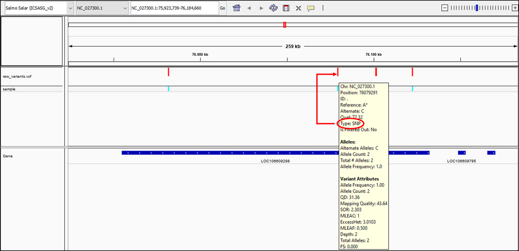

Variante SNP localizada en el archivo vcf de la secuencia SRR2006763

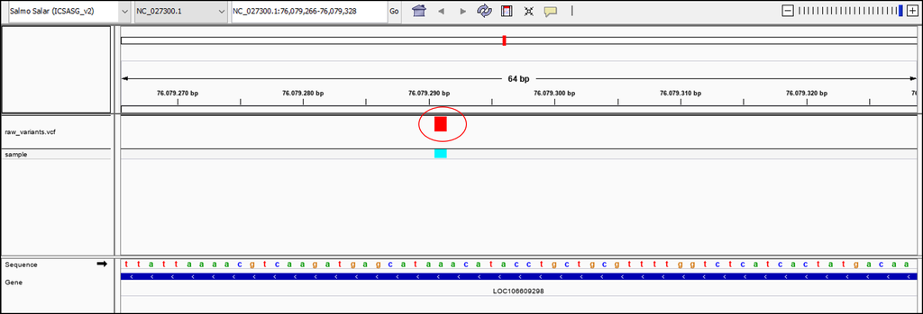

Zoom a la región seleccionada en el archivo vcf

### 7 - REFERENCIAS

Danecek, P., Auton, A., Abecasis, G., Albers, C., Banks, E., DePristo, M., . . . Durbin, R. (2011). The variant call format and VCFtools. Bioinformatics, 2156–2158.

Deatherage, E. (2020). Genome Analysis Toolkit (GATK). Obtenido de https://wikis.utexas.edu/display/bioiteam/Genome+Analysis+Toolkit+%28GATK%29+.+--+GVA2020

Cingolani, P., Platts, A., Wang, L., Coon, M., Nguyen, T., Wang, L., . . . Ruden, D. (2012). A program for annotating and predicting the effects of single nucleotide polymorphisms, SnpEff. Fly, 80-92.

Liu, X., White, S., Peng, B., Johnson, A., Brody, J., Li, A., . . . Klein, B. E. (2015). WGSA: an annotation pipeline for human genome sequencing studies. JMG, 1-3.

McCormick, R., Truong, S., & Mullet, J. (2015). RIG: Recalibration and Interrelation of Genomic Sequence Data with the GATK. G3: Genes, Genomes, Genetics, 655 - 665.

Tan, Y., Zhang, Y., Yang, H., & Yin, Z. (2020). FPfilter: A false-positive-specific filter for whole-genome sequencing variant calling from GATK. bioRxiv, 1-16.